# Production panneaux solaires EcoFlow

Author

Hugo Mabillard

## Production des panneaux solaires EcoFlow

Le jour où les panneaux ont produit le plus d’énergie fut le 17 juillet 2025 pour un total de 5487 Wh.

À l’inverse, le 24 novembre 2025 les panneaux ont produit la plus faible quantité d’énergie (0 Wh).

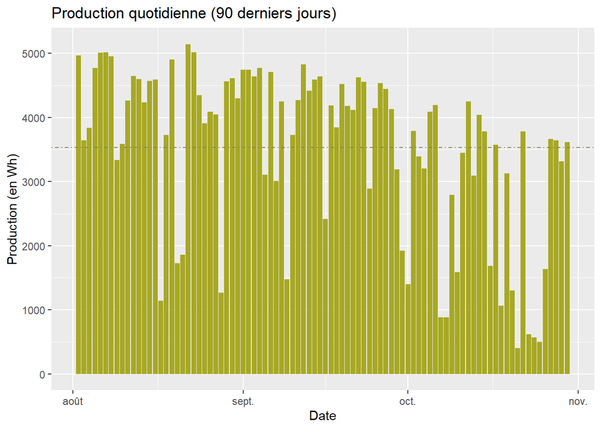

En moyenne, sur les 90 derniers jours, la production quotidienne s’élève à 3528 Wh.

Le graphique suivant compare la production entre le dernier jour (30 octobre 2026; 3612 Wh) et le jour de production max. 17 juillet 2025

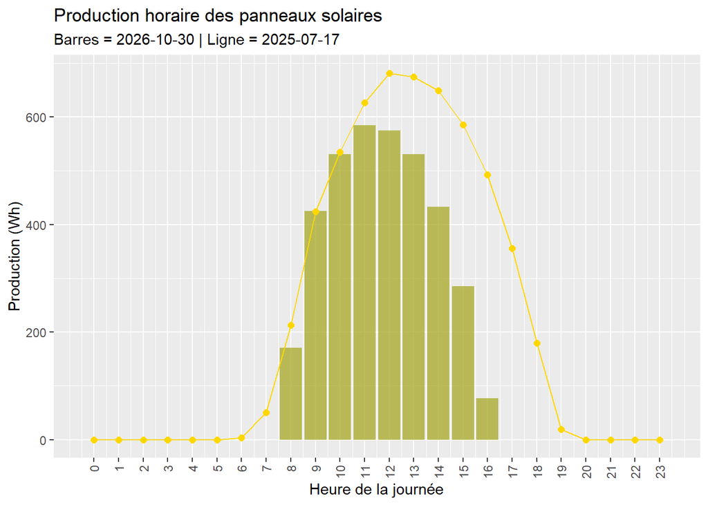

### Graphiques pour la production hebdomadaire et mensuelle

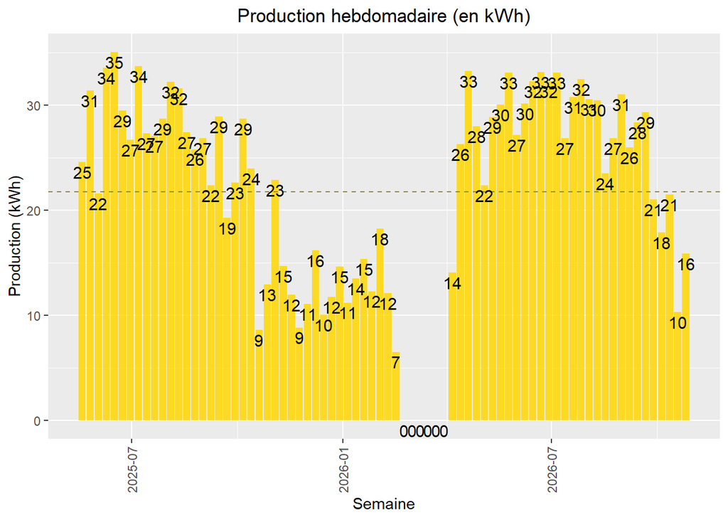

La production hebdomadaire moyenne (sans la semaine en cours) est de 21.765 kWh.

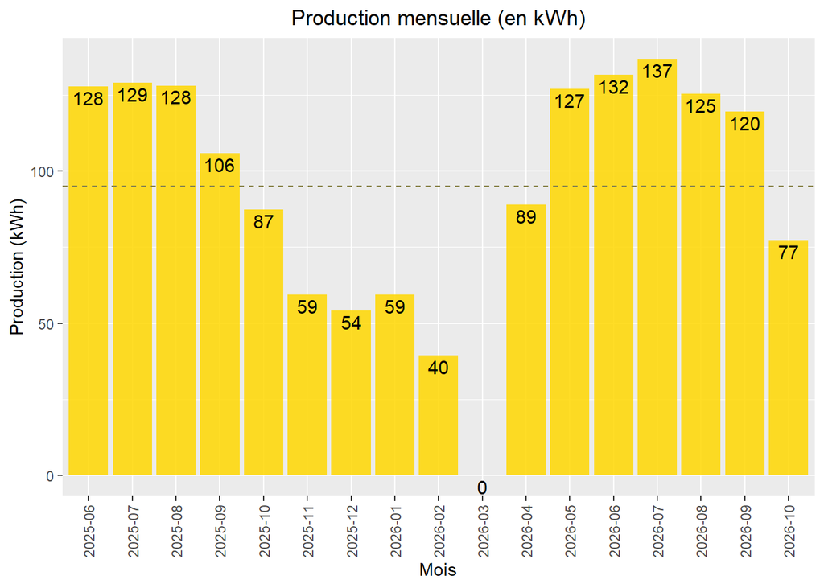

Alors que la production mensuelle moyenne (à partir de juin 2025; sans le mois en cours) est de 95 kWh.

### Classements des 10 jours les plus et les moins productifs*

*Sans les jours à production nulle

**Les 10 meilleurs jours**

| Date | Production (en Wh) |
| --- | --- |
| 2025-07-17 | 5487 |
| 2025-07-10 | 5411 |
| 2025-07-09 | 5406 |
| 2025-05-24 | 5382 |
| 2025-07-12 | 5365 |
| 2025-06-08 | 5354 |
| 2026-06-11 | 5314 |
| 2026-07-27 | 5297 |
| 2025-05-18 | 5292 |
| 2026-07-04 | 5287 |

**Les 10 moins bons jours**

| Date | Production (en Wh) |
| --- | --- |
| 2025-12-07 | 89 |
| 2025-12-30 | 135 |
| 2025-12-24 | 139 |
| 2025-11-25 | 148 |
| 2025-10-27 | 188 |
| 2026-01-09 | 215 |
| 2025-11-02 | 239 |
| 2025-10-20 | 244 |
| 2026-02-16 | 249 |
| 2026-02-12 | 256 |

**Les 5 meilleurs jours par année**

| 2025 |  | 2026 |  |
| --- | --- | --- | --- |
| Date | Production (en Wh) | Date | Production (en Wh) |
| 2025-07-17 | 5487 | 2026-06-11 | 5314 |
| 2025-07-10 | 5411 | 2026-07-27 | 5297 |
| 2025-07-09 | 5406 | 2026-07-04 | 5287 |
| 2025-05-24 | 5382 | 2026-06-13 | 5274 |
| 2025-07-12 | 5365 | 2026-07-02 | 5220 |

**Les 5 moins bon jours par année**

| 2025 |  | 2026 |  |
| --- | --- | --- | --- |
| Date | Production (en Wh) | Date | Production (en Wh) |
| 2025-10-27 | 188 | 2026-10-21 | 402 |
| 2025-11-25 | 148 | 2026-01-28 | 271 |
| 2025-12-24 | 139 | 2026-02-12 | 256 |
| 2025-12-30 | 135 | 2026-02-16 | 249 |
| 2025-12-07 | 89 | 2026-01-09 | 215 |

### Résultats divers

Nombre de jours avec production supérieure à 5 kWh: 55

Nombre de jours avec production inférieure à 1 kWh: 36

Production entre le 15 mai 2025 et le 14 mai 2026: 991.581 kWh.

Production depuis le 15 mai 2026: 666.083 kWh.

## Consommation électrique

La consommation est mesurée par le *smart meter* Shelly Pro 3 EM. Ce dispositif ne mesure que la consommation dans l’appartement. Sont donc exclus la consommation dans la cave/buanderie (lave-linge et sèche-linge) ainsi que le garage (borne de recharge).

### Consommation électrique quotidienne et horaire

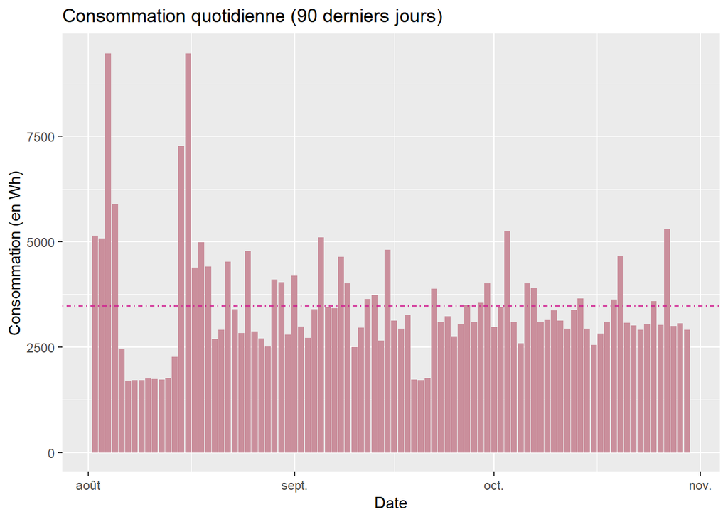

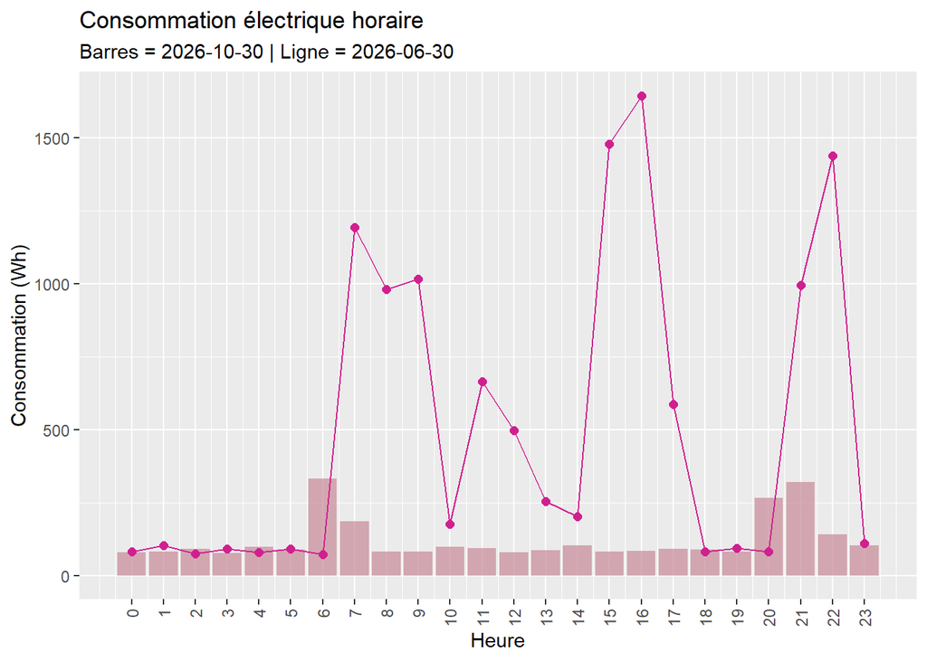

La consommation quotidienne moyenne est de 3.473 kWh.

### Consommation électrique hebdomadaire et mensuelle

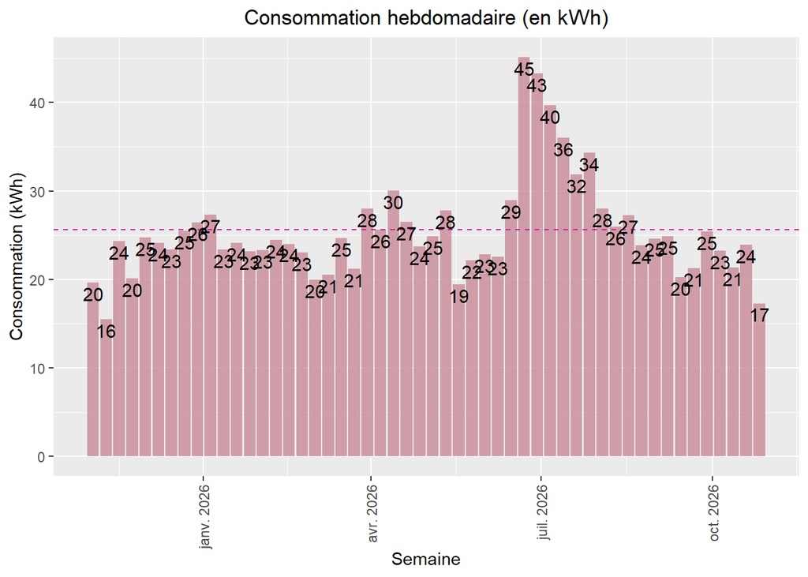

La consommation hebdomadaire moyenne (sans la semaine en cours) est de 25.611 kWh.

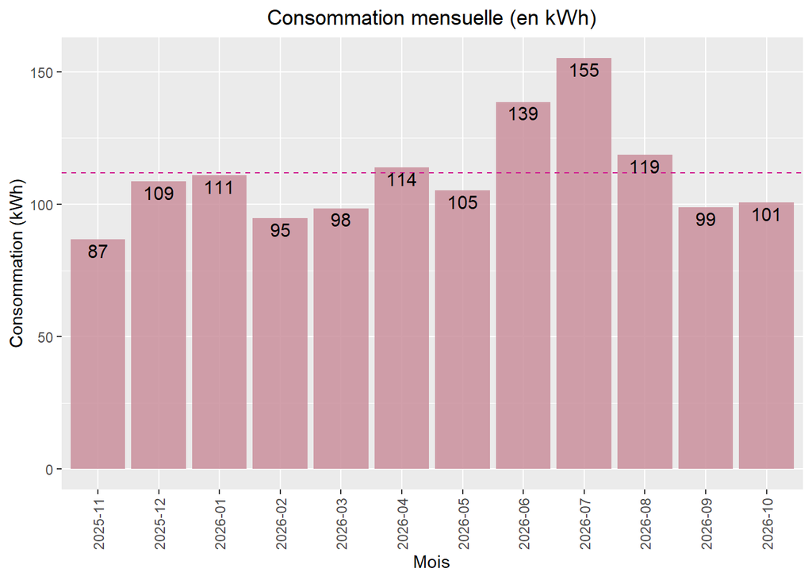

Alors que la consommation mensuelle moyenne (sans le mois en cours) est de 111.822 kWh.

## Production et consommation

Graphique combiné production et consommation électrique du dernier jour complet.

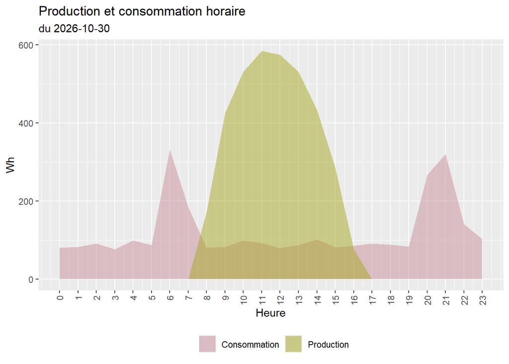

## Autoconsommation

### Autoconsommation et taux de couverture mensuels

Prise en compte de la batterie: on s’intéresse au moment où l’energie est envoyée à la maison

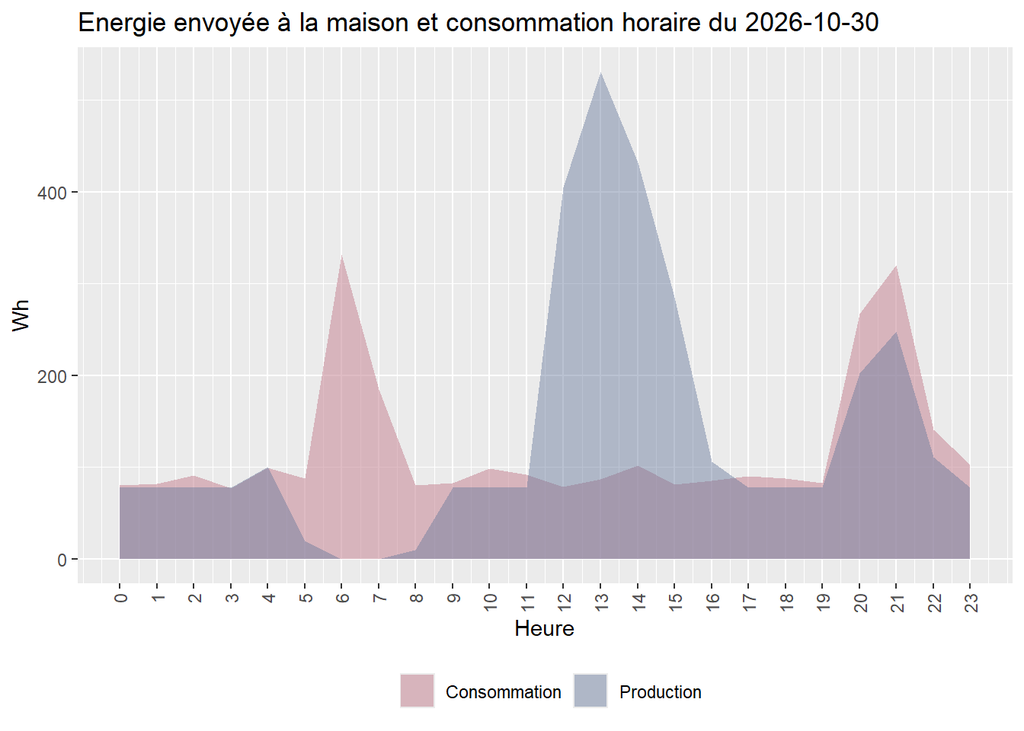

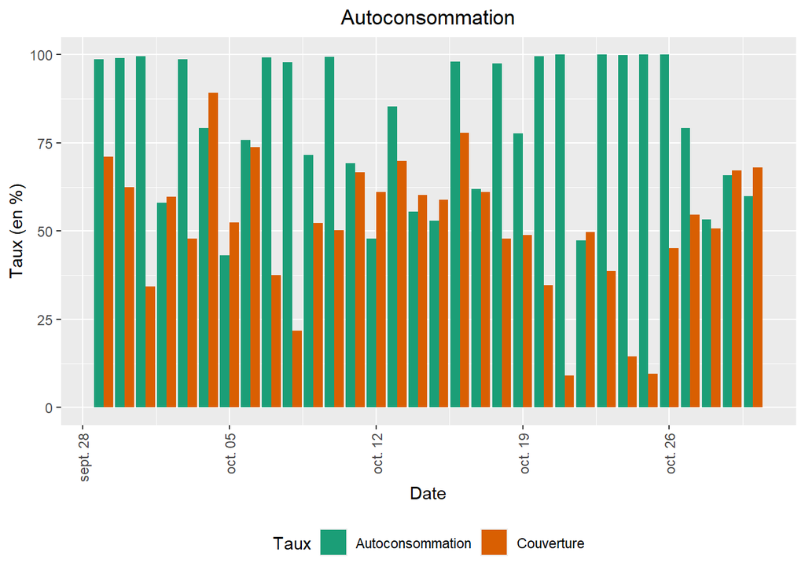

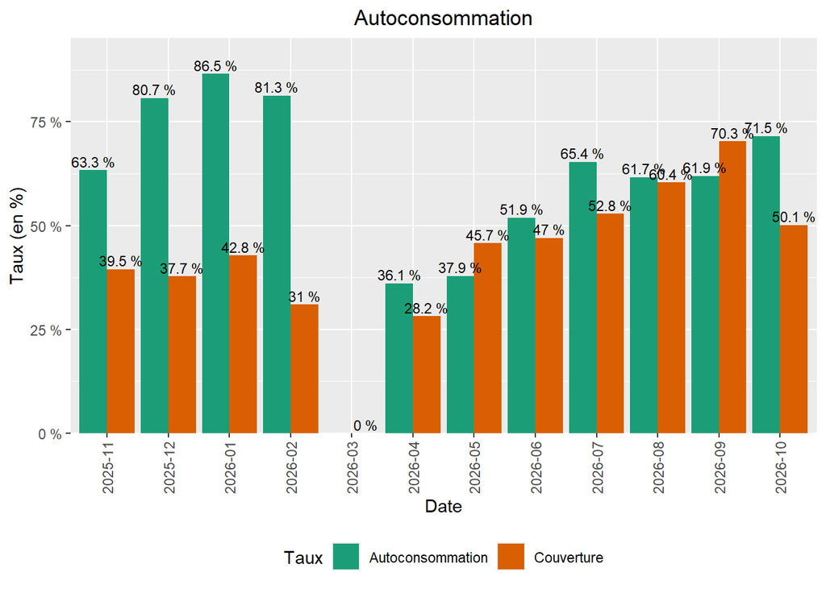

**Taux d’autoconsommation et de couverture des 10 derniers jours**

| Date | Autoconsommation (en %) | Couverture (en %) |
| --- | --- | --- |
| 2026-10-30 | 59.9 | 68 |
| 2026-10-29 | 65.8 | 67.2 |
| 2026-10-28 | 53.3 | 50.8 |
| 2026-10-27 | 79.3 | 54.7 |
| 2026-10-26 | 100 | 45.2 |
| 2026-10-25 | 100 | 9.5 |
| 2026-10-24 | 99.9 | 14.5 |
| 2026-10-23 | 100 | 38.7 |
| 2026-10-22 | 47.3 | 49.7 |
| 2026-10-21 | 100 | 9.1 |

### Alimentation depuis ou injection vers le réseau

L’injection d’énergie vers le réseau est calculée sur la base des résultats horaires (Consommation - Energie envoyée vers la maison) et diffère donc des relevés effectués par Oiken.

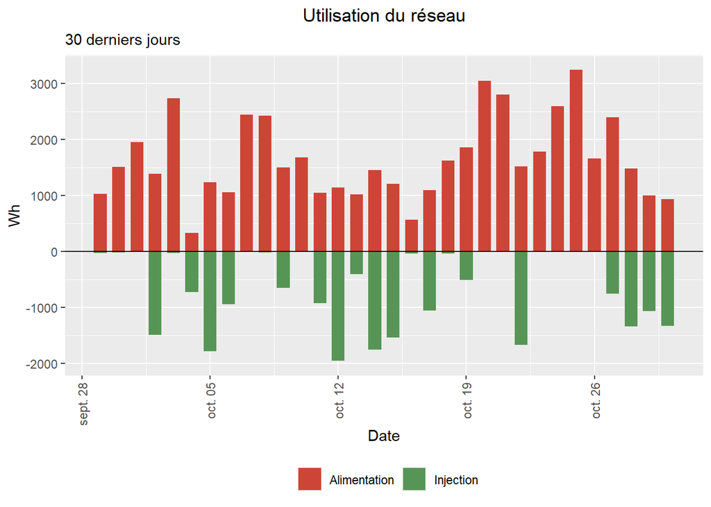

**Résumé des 10 derniers jours (en Wh)**

| Date | Consommation | Production | Alimentation depuis le réseau | Injection vers le réseau |
| --- | --- | --- | --- | --- |
| 2026-10-30 | 2914 | 3612 | 933 | 1327 |
| 2026-10-29 | 3060 | 3313 | 1004 | 1068 |
| 2026-10-28 | 3004 | 3641 | 1479 | 1338 |
| 2026-10-27 | 5296 | 3659 | 2400 | 758 |
| 2026-10-26 | 3026 | 1635 | 1659 |  |
| 2026-10-25 | 3588 | 496 | 3246 |  |
| 2026-10-24 | 3038 | 571 | 2598 | 0 |
| 2026-10-23 | 2907 | 615 | 1781 | 0 |
| 2026-10-22 | 3016 | 3781 | 1518 | 1670 |
| 2026-10-21 | 3078 | 402 | 2798 |  |